# RNA-seq to DEGs Virtual Workshop: data management, analysis, and visualization with R Studio*, GitHub, and L<sup>A</sup>T<sub>E</sub>X

Sean Bresnahan and Briana Ezray

Molecular, Cellular, and Integrative Biosciences Graduate Program, Huck Institutes of the Life Sciences, Pennsylvania State University  
Pennsylvania State University Libraries

stb5321@psu.edu

8 March 2021

# 1 Overview of workshop

## 1.1 Objectives

- To understand the importance of data/analysis transparency and to learn practical data management practices like version control and project directory structure
- To understand what GitHub is useful for in this regard, and how to use it
- To learn how to set up a computer for bioinformatic and statistical analyses in R Studio*
- To learn how to access and retrieve next generation sequencing data from [NCBI’s Short Read Archive](https://www.ncbi.nlm.nih.gov/sra)
- To understand the data types and structures involved in RNA-seq and differential gene expression analyses; what sequencing reads and gene expression count matrices are, and how to work with them
- To understand differential gene expression analysis results and how to visualize them to tell a story
- To learn how to write and work with markdown documents for reproducible data analysis
- To learn how to utilize publisher-provided L<sup>A</sup>T<sub>E</sub>X typesets for formatting analyses (and our stories informed by them) for publication.

## 1.2 Timeline

- **02/23/21, 3-5pm (EST)**: Initial setup and discussion about data transparency, management, and reproducibility | Co-hosted by [Briana Ezray](https://twitter.com/bezray2?lang=en), Research Data Librarian - STEM, Penn State University Libraries
- **03/09/21, 3-5pm (EST)**: RNA-seq analysis, from sequencing reads to gene expression count matrices
- **03/23/21, 3-5pm (EST)**: DEG analysis, from count matrices to DEGs (and what they’re good for), and finally,
- **04/06/21, 3-5pm (EST)**: Preparing markdown and L<sup>A</sup>T<sub>E</sub>X documents for scientific communication.

## 1.3 Microsoft Teams

Throughout the workshop (and beyond!), we will use the [Microsoft Teams](https://www.microsoft.com/en-us/microsoft-teams/group-chat-software) platform as a way to network among ourselves, and as a virtual “working group” for tech support. Teams is a great alternative to Slack, which integrates Microsoft Office tools rather than Google tools. You can access Teams from the web, or download the desktop/mobile app. Ideally, we will run this workshop or a variant of it again in the future, and this Team will remain open as a permanent resource. Feel free to start using our Team for all your Q&A needs :)

### 1.3.1 Office hours

If you have questions or issues while following the setup instructions, I can help you 1:1 during these times:

- Monday: 9AM-5PM (EST)
- Tuesday: 9AM-12PM (EST)
- Wednesday: 9AM-5PM (EST)
- Thursday: 9-6PM (EST)

Just message me in Teams and I’ll try to respond ASAP!

# 2 [The very *very* basics of using R](https://www.seantbresnahan.com/wp-content/uploads/2021/02/intro_to_R.html)

Thanks to Michael Axtell (PSU), [see here](https://www.seantbresnahan.com/wp-content/uploads/2021/02/intro_to_R.html) for a ~2.5 hour introduction to R and R-studio. This is just a taste of what R can do for data analysis and plotting. To learn more, the following references are highly recommended:

- [Introduction to R from CRAN](https://cran.r-project.org/doc/manuals/r-release/R-intro.pdf)
- [R for Data Science by Hadley Wickham and Garrett Grolemund](https://r4ds.had.co.nz). The definitive guide to the [tidyverse](https://www.tidyverse.org) R packages, including the very useful [ggplot2](https://ggplot2.tidyverse.org) and [dplyr](https://dplyr.tidyverse.org) packages.
- [Bioconductor](https://www.bioconductor.org) R packages for bioinformatics. A large, self-contained set of open-source R packages specific for bioinformatics.
- [Base R cheat-sheet](https://rstudio.com/wp-content/uploads/2016/10/r-cheat-sheet-3.pdf)
- [ggplot2 cheat-sheet](https://rstudio.com/wp-content/uploads/2015/03/ggplot2-cheatsheet.pdf)

# 3 Session 1: Initial setup and discussion over data transparency, management, and reproducibility

We will be focusing on data management strategies for a reproducible analysis and output workflow to facilitate transparent and reproducible research as well as support open data sharing.

More specifically, in this session you will learn how to:

1. Document your data for reusability and structure tabular data for computation.
2. Manage and organize your files using a project structure.
3. Utilize the version control software, Git, in the RStudio environment.
4. Implement a reproducible, project- based, data analysis and output workflow in RStudio.

## 3.1 Before the workshop:

1. Register for a free GitHub account (if you do not already have one).
- You can sign up for GitHub [here](https://github.com/join?ref_cta=Sign+up&ref_loc=header+logged+out&ref_page=%2F&source=header-home)
- When creating a username and selecting an email to use consider:
  - Incorporating your actual name or reusing a username from another platform so people easily know whose work they are examining.
  - Picking a username that you would want displayed in a professional context.
  - Making your username widely usable by avoiding using time or place context (for instance, referencing PSU if you will not be here permanently) ( [Happy Git and GitHub for the useR by Jennifer Bryan](https://happygitwithr.com) ).
2. Download and install Git to the computer you plan to use in this workshop.
- You can download Git [here](https://git-scm.com/downloads)
- To determine if you already have Git installed or verify that you have installed Git, in the shell or terminal enter `which git`. This will produce the path to your Git executable if it is installed.
- If you do not see a path to your Git executable, Git is not installed. Follow the instructions below. These instructions are adapted from [Happy Git and GitHub for the useR by Jennifer Bryan](https://happygitwithr.com).

**Windows**

Install Git for Windows. This will download Git and other useful tools, such as the Bash shell. - When prompted about “Adjusting your PATH environment,” select “Git from the command line and also from 3rd-party software.” - RStudio prefers that Git be installed under the path C:/Program Files, so maintain the default so that this is where Git is installed.

**macOS**

Install Git for Mac. At the link there is information for troubleshooting if the download or install does not work.

**Linux**

Install Git using the distro’s package manager.

Ubuntu or Debian Linux: sudo apt-get install git

Fedora or RedHat Linux: sudo yum install git

## 3.2 Data Management Basics

Implementing a project folder structure that you use consistently along with a file naming system is good practice as it allows you to easily navigate project contents.

### 3.2.1 File and object naming:

Using file and object naming conventions will help you more effectively find and use your data.

Some naming best practices include:

- Create brief yet meaningful names
- Avoid using spaces, dots, and special characters (&, ?, !), instead use hypthens (-) or underscores (-)
- When files are linked in a workflow, number them to indicate the order they should be run
- Denote versioning where appropriate

### 3.2.2 Project Structure:

> Project structure and descriptions adapted from [Cookiecutter Data Science](https://drivendata.github.io/cookiecutter-data-science/#cookiecutter-data-science), [R Best Practices by Krista L. DeStasio](https://kdestasio.github.io/post/r_best_practices/)), & [project_template GitHub repository - Drew Wham](https://github.com/DrewWham/project_template)

Below is an example project folder structure:

Named_Project/

|–README.md

|–R_Project

|–volume/

| |–data/

| | |–raw

| | |–interim

| | |–external

|–required

| |–requirements.R

|–source_code/

|–documents/

|–figures/

|–output/

|–.gitignore

- **Named_Project**: Root level folder denoting the project. This folder contains all folders and files related to the project and is checked into GitHub.
- **README.md**: Top-level README file outlining folder structure and files as well as file associations.
- **R_Project**: A R_Project file.
- **Volume**: A folder containing your data subset by type. This folder will not be uploaded to Github thus we will .gitignore it.
- **Data**: This folder contains data subfolders. Within this folder, are the data you will use for analysis. - **Raw**: Raw data files used in the project. These files should be treated as read-only and never altered. - **Interim**: Intermediate data that has been wrangled or transformed. - **External**: Data from third-party sources.
- **Required**: The required libraries for reproducing the R environment.
- **Source_code**: Source code or scripts for running data wrangling, analysis, and visualization.
- **Documents**: Generated documents for final reporting of the project such as manuscripts or reports.
- **Figures**: Generated figures for final reporting of the project. This should only contain figures generated by your saved source code.
- **Output**: Non-figure objects created by your source code including processed data, logs, simulation output, or model output.
- **.gitignore**: List of files not to sync with GitHub.

### 3.2.3 Setting up a RStudio Project

**Why use a RStudio Project?**

Using a RStudio Project is an easy way to keep everything you need for your analysis together in a manner that is reproducible and shareable.

It is best practice to avoid using absolute paths, such as those implemented using the `setwd()` approach, because the link to this location can easily be broken and is not easily reproduced by others. Jenny Bryan explains this by stating “The chance of the `setwd()` command having the desired effect - making the file paths work - for anyone besides it’s author is 0%. It’s also unlikely to work for the author one or two years or computers from now. The project is not self-contained and portable. To recreate and perhaps extend this plot, the lucky recipient will need to hand edit one or more paths to reflect where the project has landed on their machine” ( [Project-oriented workflow by Jenny Bryan](https://www.tidyverse.org/blog/2017/12/workflow-vs-script/) )

Using RStudio Projects allows you to use relative paths rather than absolute paths and store settings for a particular project. An RStudio Project relative path points to the top level folder where your .Rproj file is located.

**How to set up an RStudio Project:**

1. Click the *R Project: (None)* button in the top right corner of the RStudio console.
2. Select *New Directory*
3. Select *New Project*
4. Give your directory a name and locate where on your computer you want this project directory and RStudio project to be stored
5. Click *Create Project*

##### 3.2.3.0.1 Exercise 1:

1. Navigate to your project folder on your desktop. Look through each of the folders and consider what you would put in each.
2. Open RStudio and using the below directions, designate this folder as your project folder.
   - Open RStudio.
   - Click the RProject button in the top right of the console.
   - Select New Project.
   - Select Existing Directory.
   - Browse to the Project folder on your Desktop and select this folder.
   - Click Create Project.

## 3.3 Key Elements For Good R Code

1. It is a bad habit to rely on the settings of a previous RStudio session. To prevent RStudio from saving your settings from a previous session, you can change the following setting:
- Find your preferences in RStudio
- Under the general tab
  - Uncheck “Restore .RData”
  - Select “never” for Save workspace…

( [R for Data Science by Wickham & Grolemund](https://r4ds.had.co.nz/workflow-projects.html), [Project-oriented workflow by Jenny Bryan](https://www.tidyverse.org/blog/2017/12/workflow-vs-script/) )

2. Make your code readable.
- Organize your code to make it more readable.
  - Start your code with a brief description of what it does.
  - Make run requirements and dependencies clear by putting `library()` loading and functions at the top.
- Use comments to describe the purpose of the code
- Use meaningful object naming
- Use version control
- Adopt a coding style

( [Why I want to write nice R cod by Daniel Falster](https://nicercode.github.io/blog/2013-04-05-why-nice-code/), [R Best Practices by Krista L. DeStasio](https://kdestasio.github.io/post/r_best_practices/) )

3. Make your code reliable
- Check that your code is error free

( [Why I want to write nice R cod by Daniel Falster](https://nicercode.github.io/blog/2013-04-05-why-nice-code/) )

## 3.4 Version Control with Git and GitHub

> Instructions below are either from or adapted from [Happy Git and GitHub for the useR by Jennifer Bryan](https://happygitwithr.com).

### 3.4.1 Configure Git with your user credentials:

*Windows users will want to use the Git Bash shell!

In the shell or terminal, type the following with your name and email as they are associated with your GitHub account:

`git config --global user.name ‘enteryournamehere’`

`git config --global user.email ‘enteryouremailhere’`

Confirm that you have configured Git with your credentials, using the following code in the shell or terminal:

`Git config --global --list`

### 3.4.2 Connect to GitHub:

1. Login to GitHub at https://github.com
2. Create a new repository by either clicking the “New repository” button or from your personal profile clicking “Repositories” > “New”
3. You will be prompted to:
   - Name your repository: Set your repository name to “CFH_RWorkshop2”
   - Add a description: Include the following text: “testing setup”
   - Select private as the visibility
   - Select to initialize this repository with a README
4. Create the repository
5. By clicking the “Clone or Download” button, copy the HTTPS clone URL.

### 3.4.3 Clone GitHub repository on your computer in RStudio:

1. Open RStudio
2. Start a new project in RStudio: File > New Project > Version Control > Git.
3. Under “Repository URL,” paste the copy of the HTTPS clone URL for your GitHub repository you created above.
4. Check that the default project directory name matches the name of your GitHub repository and accept.
5. Note where the R Project will be saved locally.
6. Select “Open in new session”
7. Click “Create Project”
8. Check that you can see the GitHub README.md in the RStudio file browser pane.
- Connecting RStudio to Git can be complicated because of variability between operating systems and versions of operating systems. To confirm that Git properly setup, follow the following steps:

**Mac OS**

1. In RStudio, select Preferences > Git/SVN
2. Check to see if a path to a file in the Git executable window exists.
3. If not, return to your shell or terminal and type which git. This will produce the path to your Git executable if it is installed.
4. Type or paste in the full path to your git executable: e.g. /usr/bin/git into the Git executable box on R Studio Git/SVN screen.

**Windows**

1. In RStudio, Go Tools > Global options > Git/SVN
2. Check to see if a path to a file in the Git executable window exists.
3. If not, return to your shell or terminal and type which git. This will produce the path to your Git executable if it is installed.
4. Type or paste in the full path to your git executable: e.g. /usr/bin/git into the Git executable box on R Studio Git/SVN screen.
- If Git is still not properly connected, following this [link](https://happygitwithr.com/rstudio-see-git.html) to see steps to troubleshoot.

### 3.4.4 Make local changes, save, and commit to Git:

1. In RStudio, add the line “This is a line from RStudio” in the README.md file and click save
2. Click the “Git” tab in the upper right pane
3. Check “Staged” box for README.md
4. If you’re not already in the Git pop-up, click “Commit.”
5. Type a message in “Commit message,” such as “Commit from RStudio.”
6. Click “Commit”

### 3.4.5 Push your local changes online to GitHub:

1. Click the green “Push” button to send your local changes online at GitHub.
2. Go to GitHub online to confirm that the local change was submitted to GitHub online.

# 4 Session 2: RNA-seq analysis, from sequencing reads to gene expression count matrices

In this session, we will retrieve (a subset of) sequencing reads from an RNA-seq experiment exploring tissue-specific gene expression profiles of nurse, forager, and winter honey bees. The goal of this experiment was to test hypotheses about the relationship between the winter bee phenotype and diapause, a genetically programmed state of dormancy which is triggered by environmental cues in advance of adverse conditions, such as winter in temperate areas or hot and dry conditions in tropical areas (Denlinger & Armbruster, 2013; Saulich & Musolin, 2017; Sim & Denlinger, 2013). The physiology of winter worker bees (and long-lived summer bees) suggest that they are in a diapause-like state [see Bresnahan et al. *in prep*… i.e., *hopefully someday soon* :) ]

## 4.1 Example experiment: methods

Sample collection was conducted as described in (Doke et al., 2019). Briefly, four colonies headed by naturally mated honey bee queens from four different commercial breeders were established at a Pennsylvania State University apiary in central Pennsylvania. Colonies were maintained according to standard apicultural practices. More than 6 weeks after establishment (July 2013), which is sufficient time for the eggs laid by the queens to develop into adult nurses and foragers, 6 summer nurse and forager bees per colony were collected on dry ice and stored at -80$^\circ$C. Winter bees were collected 5 months later (December 2013) from within their respective winter clusters.

After removal from storage at -80$^\circ$C, sampled bees were submerged in Invitrogen$^{TM}$ Ambion$^{TM}$ RNAlater$^{TM}$ Stabilization Solution (ThermoFisher Scientific) to prevent RNA degradation, and dissected on a platform surrounded by dry ice. To collect flight muscle tissue, legs and wings were detached from thorax and discarded, leaving flight muscles and exoskeleton. To collect abdominal fat body tissues, abdomens were allowed to thaw RNAlater$^{TM}$ on ice. Digestive tracts and reproductive organs were then removed by gently pulling from the stinger using forceps, leaving the eviscerated abdomen with fat body. Dissected tissues for each worker were individually placed in a 1.5ml nuclease-free microcentrifuge tube (Denville Scientific Inc., Metuchen, NJ) and kept at -80$^\circ$C.

For each of the 4 colonies, samples of the same tissue and bee type were pooled (6 bees per sample). Pooled samples (4 colonies x 3 groups x 2 tissues = 24 samples, total) were homogenized using an automated homogenizer (Thermo Savant FastPrep$^{TM}$ FP120 Cell Disrupter System) for 3 intervals of 45 seconds at the highest speed setting, using 3-6 2mm zirconia bees (BioSpec Products, Inc.). Homogenates were stored for later use in RNA extraction via the RNeasy Plus Universal kit (QIAGEN) for RNA sequencing (RNA-seq). RNA libraries were prepared by the Sequencing and Genomic Technologies Shared Resource at the Duke Center for Genomic and Computational Biology, Durham, NC, and sequenced on an Illumina HiSeq 4000 platform.

## 4.2 Methods (ClEaRlY eXpLaInEd)

What does all of this mean? If you are super new to RNA-sequencing and Next Generation Sequencing (NGS) technologies in general, please watch this excellent and “gentle” introduction to RNA-seq by Josh Starmer (previously of North Carolina State University)

- [A gentle introduction to RNA-seq](https://www.youtube.com/watch?v=tlf6wYJrwKY&t=245s)

For reference, here is a workflow diagram depicting a typical RNA-seq experiment. We begin at part III, with the `.fastq` files generated by the sequencing facility.

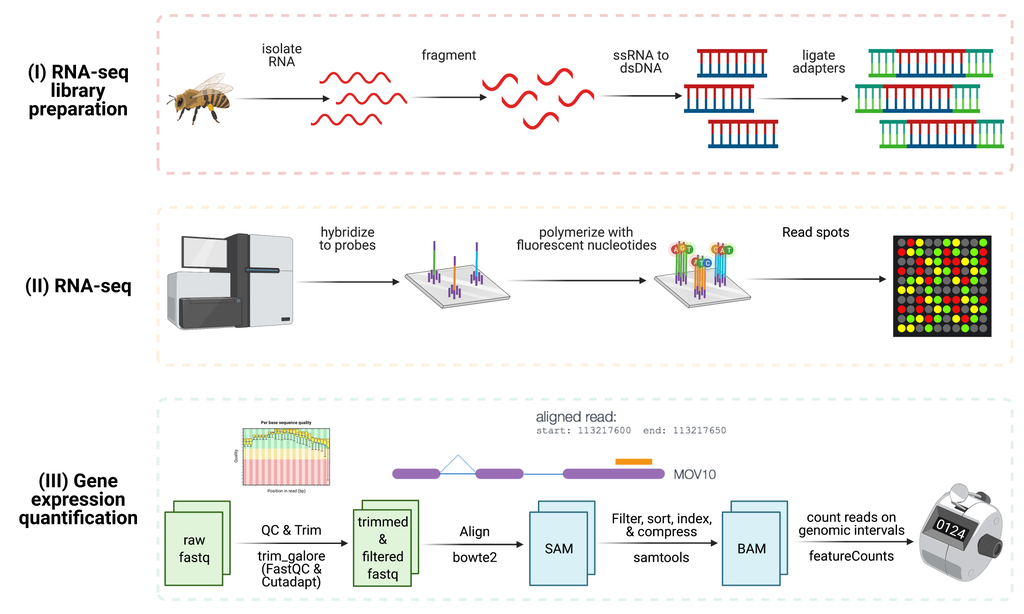

**An RNA-seq workflow**: a typical RNA-seq experiment can be thought of as consisting of 3 main phases: (I) RNA-seq library preparation, (II) RNA sequencing, and (III) Analysis. In our experiment, analysis consists of trimming sequencing adapters from reads, checking the reads for quality control metrics, aligning the reads to a reference genome, and counting the reads on genomic intervals. Many different tools have been created for each step of the analysis pipeline; we will compare and contrast some of the main differences between popular tools/methods in a later section.

[“What are those?”](https://www.youtube.com/watch?v=PGT-CMuhiB8) you ask? I’ll allow Illumina to explain for now:

- [fastq files explained](https://support.illumina.com/bulletins/2016/04/fastq-files-explained.html)

Our job is to take these sequencing reads, align them to a reference genome (the honey bee genome, in this case), and generate a count of the number of reads mapping to gene transcripts (our measure of gene expression by RNA-seq!)

## 4.3 Setup

### 4.3.1 Bash (*the catch)

Alright, I hate to tell you this, but, no matter how hard you try to avoid it you *will* need to set a few things up in bash (if using a Mac, you can work in bash via Terminal). The algorithms used to align NGS reads to a reference genome are simply too resource intensive to implement in R directly, and many excellent command line tools are readily available to download and install. To make things easier for us, we will use a package management system (Conda) which will effectively reduce the number of opportunities for Murphy’s law to manifest. The second half of this workshop covers the world of R Markdown, wherein bash code chunks can be written and run while knitting the markdown document. Therefore it *is* technically possible to complete the entirety of RNA-seq and DEG analysis within R… *once you know things will run smoothly in bash :)* More on this later…

#### 4.3.1.1 Conda

[Download an installer for Miniconda here.](https://docs.conda.io/en/latest/miniconda.html) Follow the instructions, then open a Terminal window once installation completes.

After installing conda you will need to add the bioconda channel as well as the other channels bioconda depends on. It is important to add them in this order so that the priority is set correctly (that is, conda-forge is highest priority).

The conda-forge channel contains many general-purpose packages not already found in the defaults channel. In your terminal:

```bash
conda config --add channels defaults
conda config --add channels bioconda
conda config --add channels conda-forge
```

Now, we need to create a Conda “environment” in which to install a few bioinformatics tools:

```bash
conda create -n bioinformatics
```

Each time you open a new Terminal window, it is operating within a base environment called `.bash_profile`. We want to work within our new bioinformatics Conda environment:

```bash
conda activate bioinformatics
```

Next, we can install most of the tools we need directly through Conda. The first of these tools are called [**samtools**](http://www.htslib.org) and [**bedtools**](https://bedtools.readthedocs.io/en/latest/), suites of programs for interacting with high-throughput sequencing data and for conducting operations on genomic intervals. We won’t use them directly in this workshop, but they are often prerequisite for other bioinformatics tools. Next, we will use NCBI’s [**SRA-toolkit**](https://github.com/ncbi/sra-tools) to interface with SRA.

```bash
conda install -c bioconda samtools

conda install -c bioconda bedtools

conda install -c bioconda sra-tools
```

#### 4.3.1.2 Command line tools

Additionally, we will install [**trim_galore**](https://www.bioinformatics.babraham.ac.uk/projects/trim_galore/), and [**kallisto**](https://pachterlab.github.io/kallisto/). Trim_galore is a wrapper program around [**cutadapt**](https://cutadapt.readthedocs.io/en/stable/) - which is used to trim sequencing adapters from sequencing reads (more on this later) - and [**FastQC**](https://www.bioinformatics.babraham.ac.uk/projects/fastqc/) - which creates reports detailing quality control metrics of the sequencing reads (more on this later, too). Kallisto is the tool we will use to generate transcript abundance estimates for calculating gene expression. To install trim_galore and kallisto, follow each link (above) and associated download and install instructions.

## 4.4 The Short Read Archive (SRA)

Excellent - now lets get some data and run it through the pipeline! First, let’s see what it looks like on the depository website. Go to https://trace.ncbi.nlm.nih.gov/Traces/study/? and search the **SRA Study** accession [`SRP242105`](https://trace.ncbi.nlm.nih.gov/Traces/study/?acc=SRP242105&o=acc_s%3Aa). This GUI page displays the data and metadata associated with **BioProject** accession [`PRJNA601517`](https://www.ncbi.nlm.nih.gov/bioproject/PRJNA601517).

*Definitions*: **BioProject** submission describes the goal of the sequencing study, whereas the **SRA Study** (SRA prefix **SRP**) is an object that contains the project metadata describing a sequencing study or project.

The 24 rows of the SRA Run Selector spreadsheet on this page describe the 24 individual sequencing runs (SRA prefix **SRR**), or objects that contain actual sequencing data for a particular sequencing experiment.

## 4.5 Short tutorial

Before you throw your laptop at the wall, no, I’m not going to make you try to download 120+ Gb of data for this tutorial (unless you really want to). Instead, we will first work with a single, smaller run from an unrelated honey bee RNA-seq project. Then, we will work with synthetic runs I generated by sub-setting the real runs, which you can download here:

- [Synthetic SRP242105 for full tutorial](https://drive.google.com/file/d/1h9318eWOoCKgBX27g9pSARDUgWWF-XTs/view?usp=sharing)

*Note: total file size is ~7 Gb. I recommend downloading these on campus/etc. internet and doing so ASAP!*

First, [clone the workshop GitHub repository](https://github.com/sbresnahan/RNAseq-to-DEGs.git). In terminal:

```bash
# Set DIR to the directory on your local machine where you'd like to clone the repository
DIR="wherever/you/want/to/put/this/directory"
git clone https://github.com/sbresnahan/RNAseq-to-DEGs.git ${DIR}
```

### 4.5.1 Retrieve data from SRA

In the full-scale run-through, we will see how to use the Metadata and Accession List files to avoid manually typing out an array accessions, but for this tutorial, we only need to retrieve one run. Specifically, we will retrieve an RNA sequencing run (accession [`SRR13397503`](https://trace.ncbi.nlm.nih.gov/Traces/sra/?run=SRR13397503)) of a honey bee brain from BioProject accession [`PRJNA691031`](https://www.ncbi.nlm.nih.gov/bioproject/PRJNA691031) which describes a study assessing transcriptomic responses of the honey bee brain to infection with Deformed Wing Virus (DWV). This run is much smaller (~800 Mb) which should download relatively quickly. Since we are only retrieving one run, we don’t really need to tell bash that we’re working with a list of accessions, but let’s walk through the logic anyhow. In terminal:

```bash
SRA_LIST=("SRR13397503")
```

A bash array typically contains more than one entry, separated by spaces, e.g.:

```bash
egSRA_LIST=("SRR13397503" "SRR0000000" "SRR0000009")
```

Now, we want to retrieve each sequencing run listed in the array `SRA_LIST` by iterating over each entry in the array and issuing the `sra-tools` commands `prefetch` (to retrieve the **SRR** object) and `fasterq-dump` to split the retrieved `.sra` file into our paired-end sequencing reads in `.fastq` format. Before we do this, we should set the `sra-tools` download directory to the `volume/external` directory our cloned GitHub repository. In terminal:

```bash
EXT_DIR="${DIR}/volume/external"
echo "/repository/user/main/public/root = \"$EXT_DIR\"" > $HOME/.ncbi/user-settings.mkfg
# Note: you may want to set this back to the default directory '$HOME/ncbi/public/sra' when you are done with this project.
```

Now, we will tell bash to iterate over each index `i` of `SRA_LIST` and issue the `prefetch` and `fasterq-dump` commands on the entry at index `i` of `SRA_LIST`. Be sure to set the output `-O` flag of the latter command to `EXT_DIR`. *Note*: in bash, retrieving the value associated with an object requires referencing the object with `${object}`, as `object` retrieves the object itself:

```bash
for i in "${SRA_LIST[@]}"; do
prefetch ${i}
fasterq-dump -O ${EXT_DIR} ${i}
done
```

If all goes well, you will see some output in terminal like this:

```
(bioinformatics) Seans-MacBook-Pro:tutorial sbresnahan$ prefetch SRR13397503
2021-03-03T11:38:27 prefetch.2.9.3: 1) Downloading 'SRR13397503'...
2021-03-03T11:38:27 prefetch.2.9.3:  Downloading via fasp...
2021-03-03T11:39:32 prefetch.2.9.3:  fasp download succeed
2021-03-03T11:39:32 prefetch.2.9.3: 1) 'SRR13397503' was downloaded successfully
2021-03-03T11:39:32 prefetch.2.9.3: 'SRR13397503' has 0 unresolved dependencies

(bioinformatics) Seans-MacBook-Pro:tutorial sbresnahan$ fasterq-dump SRR13397503
spots read      : 8,879,024
reads read      : 17,758,048
reads written   : 17,758,048
```

which tells us that the **SRR** object was retrieved successfully and split into paired-end `.fastq` files containing 17,758,048 reads.

### 4.5.2 Trim adapters

Now that we have our `.fastq` files, we will trim off any adapter sequences (and assess our reads for various quality control metrics) with `trim_galore`:

```bash
# Go to the directory containing our .fastq files
cd ${DIR}/data/raw

# Create a list of all files ending in .fastq
FILE_LIST=*.fastq

# Call trim_galore with --fastqc flag set to run FastQC on the trimmed reads.
# Set the -j flag to the number of threads to run on (e.g., 2-4).
# Set the --paired flag to say we are working with paired-end reads.
# Set the -o flag to the `volume/interim' directory of our project.
trim_galore --fastqc -j 4 --paired ${FILE_LIST[*]} -o ${DIR}/volume/interim
```

Since our `.fastq` files are named by **SRR** accession, they will essentially sort numerically, so we can be sure that the entries in `FILE_LIST` consist of mate pairs 1 and 2, respectively, for each run, one after another, which is what `trim_galore --paired` expects. If all goes well, you will see some output in terminal like this:

```
(bioinformatics) Seans-MacBook-Pro:tutorial sbresnahan$ trim_galore --fastqc -j 4 --paired ${FILE_LIST[*]} -o ${OUT_DIR}
Path to Cutadapt set as: 'cutadapt' (default)
Cutadapt seems to be working fine (tested command 'cutadapt --version')
Cutadapt version: 1.18
Cutadapt seems to be using Python 3! Proceeding with multi-core enabled Cutadapt using 4 cores
Parallel gzip (pigz) detected. Proceeding with multicore (de)compression using 4 cores

No quality encoding type selected. Assuming that the data provided uses Sanger encoded Phred scores (default)

Output will be written into the directory: /Volumes/Sean/RNAseqWorkshop/data/mod/tutorial/


AUTO-DETECTING ADAPTER TYPE
===========================
Attempting to auto-detect adapter type from the first 1 million sequences of the first file (>> SRR13397503_1.fastq <<)

Found perfect matches for the following adapter sequences:
Adapter type    Count   Sequence    Sequences analysed  Percentage
Illumina    415 AGATCGGAAGAGC   1000000 0.04
smallRNA    7   TGGAATTCTCGG    1000000 0.00
Nextera 0   CTGTCTCTTATA    1000000 0.00
Using Illumina adapter for trimming (count: 415). Second best hit was smallRNA (count: 7)

Writing report to '/Volumes/Sean/RNAseqWorkshop/data/mod/tutorial/SRR13397503_1.fastq_trimming_report.txt'

SUMMARISING RUN PARAMETERS
==========================
Input filename: SRR13397503_1.fastq
Trimming mode: paired-end
Trim Galore version: 0.6.4_dev
Cutadapt version: 1.18
Python version: 3.7.9
Number of cores used for trimming: 4
Quality Phred score cutoff: 20
Quality encoding type selected: ASCII+33
Adapter sequence: 'AGATCGGAAGAGC' (Illumina TruSeq, Sanger iPCR; auto-detected)
Maximum trimming error rate: 0.1 (default)
Minimum required adapter overlap (stringency): 1 bp
Minimum required sequence length for both reads before a sequence pair gets removed: 20 bp
Running FastQC on the data once trimming has completed

Cutadapt seems to be reasonably up-to-date. Setting -j 4
Writing final adapter and quality trimmed output to SRR13397503_1_trimmed.fq


  >>> Now performing quality (cutoff '-q 20') and adapter trimming in a single pass for the adapter sequence: 'AGATCGGAAGAGC' from file SRR13397503_1.fastq <<<
This is cutadapt 1.18 with Python 3.7.9
Command line parameters: -j 4 -e 0.1 -q 20 -O 1 -a AGATCGGAAGAGC SRR13397503_1.fastq
Processing reads on 4 cores in single-end mode ...
Finished in 129.62 s (15 us/read; 4.11 M reads/minute).

=== Summary ===

Total reads processed:               8,879,024
Reads with adapters:                 1,634,614 (18.4%)
Reads written (passing filters):     8,879,024 (100.0%)

Total basepairs processed: 1,091,742,113 bp
Quality-trimmed:              16,277,494 bp (1.5%)
Total written (filtered):  1,073,274,193 bp (98.3%)

=== Adapter 1 ===

Sequence: AGATCGGAAGAGC; Type: regular 3'; Length: 13; Trimmed: 1634614 times.

No. of allowed errors:
0-9 bp: 0; 10-13 bp: 1

Bases preceding removed adapters:
  A: 46.3%
  C: 17.1%
  G: 13.1%
  T: 23.5%
  none/other: 0.0%

Overview of removed sequences
length  count   expect  max.err error counts
1   1396321 2219756.0   0   1396321
2   151035  554939.0    0   151035
3   59643   138734.8    0   59643
4   15530   34683.7 0   15530
5   3209    8670.9  0   3209
6   1227    2167.7  0   1227
7   354 541.9   0   354
8   58  135.5   0   58
9   171 33.9    0   91 80
10  183 8.5 1   21 162
11  181 2.1 1   36 145
12  157 0.5 1   26 131
13  90  0.1 1   13 77
14  260 0.1 1   39 221
15  146 0.1 1   21 125
16  221 0.1 1   69 152
17  251 0.1 1   66 185
18  241 0.1 1   104 137
19  263 0.1 1   133 130
20  189 0.1 1   100 89
21  366 0.1 1   223 143
22  196 0.1 1   112 84
23  120 0.1 1   58 62
24  241 0.1 1   146 95
25  174 0.1 1   107 67
26  214 0.1 1   140 74
27  406 0.1 1   292 114
28  149 0.1 1   52 97
29  128 0.1 1   85 43
30  142 0.1 1   102 40
31  217 0.1 1   157 60
32  108 0.1 1   67 41
33  258 0.1 1   196 62
34  71  0.1 1   31 40
35  171 0.1 1   137 34
36  115 0.1 1   82 33
37  132 0.1 1   114 18
38  274 0.1 1   208 66
39  59  0.1 1   28 31
40  52  0.1 1   38 14
41  60  0.1 1   40 20
42  65  0.1 1   47 18
43  54  0.1 1   33 21
44  29  0.1 1   25 4
45  40  0.1 1   27 13
46  54  0.1 1   39 15
47  65  0.1 1   50 15
48  57  0.1 1   50 7
49  24  0.1 1   15 9
50  38  0.1 1   29 9
51  30  0.1 1   21 9
52  32  0.1 1   24 8
53  29  0.1 1   20 9
54  31  0.1 1   21 10
55  19  0.1 1   13 6
56  24  0.1 1   21 3
57  21  0.1 1   16 5
58  21  0.1 1   16 5
59  18  0.1 1   10 8
60  11  0.1 1   5 6
61  15  0.1 1   8 7
62  10  0.1 1   7 3
63  7   0.1 1   5 2
64  7   0.1 1   4 3
65  13  0.1 1   9 4
66  9   0.1 1   3 6
67  8   0.1 1   3 5
68  4   0.1 1   3 1
69  10  0.1 1   6 4
70  5   0.1 1   0 5
71  8   0.1 1   4 4
72  6   0.1 1   2 4
73  4   0.1 1   0 4
74  6   0.1 1   1 5
75  70  0.1 1   2 68
76  59  0.1 1   4 55
77  50  0.1 1   2 48
78  35  0.1 1   3 32
79  12  0.1 1   0 12
80  11  0.1 1   0 11
81  9   0.1 1   1 8
82  7   0.1 1   1 6
83  3   0.1 1   0 3
84  2   0.1 1   0 2
85  2   0.1 1   1 1
87  1   0.1 1   0 1
88  1   0.1 1   0 1
89  1   0.1 1   0 1
90  2   0.1 1   0 2
91  3   0.1 1   0 3
92  1   0.1 1   0 1
94  2   0.1 1   0 2
95  1   0.1 1   0 1
96  1   0.1 1   0 1
97  4   0.1 1   0 4
98  10  0.1 1   0 10
99  9   0.1 1   0 9
100 5   0.1 1   0 5
101 2   0.1 1   0 2
102 3   0.1 1   0 3
104 1   0.1 1   0 1
105 3   0.1 1   0 3
106 2   0.1 1   0 2
107 4   0.1 1   0 4
108 10  0.1 1   0 10
109 3   0.1 1   0 3
113 2   0.1 1   0 2
114 3   0.1 1   0 3
115 1   0.1 1   0 1
116 2   0.1 1   0 2
117 4   0.1 1   0 4
119 4   0.1 1   0 4
120 3   0.1 1   0 3
121 3   0.1 1   0 3
122 9   0.1 1   0 9
123 11  0.1 1   0 11
124 53  0.1 1   0 53
125 33  0.1 1   1 32


RUN STATISTICS FOR INPUT FILE: SRR13397503_1.fastq
=============================================
8879024 sequences processed in total
The length threshold of paired-end sequences gets evaluated later on (in the validation step)

Writing report to '/Volumes/Sean/RNAseqWorkshop/data/mod/tutorial/SRR13397503_2.fastq_trimming_report.txt'

SUMMARISING RUN PARAMETERS
==========================
Input filename: SRR13397503_2.fastq
Trimming mode: paired-end
Trim Galore version: 0.6.4_dev
Cutadapt version: 1.18
Python version: 3.7.9
Number of cores used for trimming: 4
Quality Phred score cutoff: 20
Quality encoding type selected: ASCII+33
Adapter sequence: 'AGATCGGAAGAGC' (Illumina TruSeq, Sanger iPCR; auto-detected)
Maximum trimming error rate: 0.1 (default)
Minimum required adapter overlap (stringency): 1 bp
Minimum required sequence length for both reads before a sequence pair gets removed: 20 bp
Running FastQC on the data once trimming has completed
```

```
Cutadapt seems to be reasonably up-to-date. Setting -j -j 4
Writing final adapter and quality trimmed output to SRR13397503_2_trimmed.fq


  >>> Now performing quality (cutoff '-q 20') and adapter trimming in a single pass for the adapter sequence: 'AGATCGGAAGAGC' from file SRR13397503_2.fastq <<<
This is cutadapt 1.18 with Python 3.7.9
Command line parameters: -j 4 -e 0.1 -q 20 -O 1 -a AGATCGGAAGAGC SRR13397503_2.fastq
Processing reads on 4 cores in single-end mode ...
Finished in 133.26 s (15 us/read; 4.00 M reads/minute).

=== Summary ===

Total reads processed:               8,879,024
Reads with adapters:                 2,415,894 (27.2%)
Reads written (passing filters):     8,879,024 (100.0%)

Total basepairs processed: 1,090,402,568 bp
Quality-trimmed:              14,107,581 bp (1.3%)
Total written (filtered):  1,072,875,571 bp (98.4%)

=== Adapter 1 ===

Sequence: AGATCGGAAGAGC; Type: regular 3'; Length: 13; Trimmed: 2415894 times.

No. of allowed errors:
0-9 bp: 0; 10-13 bp: 1

Bases preceding removed adapters:
  A: 52.4%
  C: 14.7%
  G: 16.6%
  T: 16.3%
  none/other: 0.0%

Overview of removed sequences
length  count   expect  max.err error counts
1   1924002 2219756.0   0   1924002
2   312286  554939.0    0   312286
3   139672  138734.8    0   139672
4   23493   34683.7 0   23493
5   3522    8670.9  0   3522
6   1554    2167.7  0   1554
7   552 541.9   0   552
8   112 135.5   0   112
9   476 33.9    0   131 345
10  450 8.5 1   52 398
11  296 2.1 1   60 236
12  364 0.5 1   119 245
13  153 0.1 1   33 120
14  312 0.1 1   63 249
15  207 0.1 1   63 144
16  224 0.1 1   113 111
17  365 0.1 1   113 252
18  287 0.1 1   172 115
19  509 0.1 1   303 206
20  117 0.1 1   43 74
21  123 0.1 1   78 45
22  223 0.1 1   139 84
23  480 0.1 1   279 201
24  422 0.1 1   218 204
25  541 0.1 1   382 159
26  266 0.1 1   133 133
27  416 0.1 1   314 102
28  118 0.1 1   58 60
29  184 0.1 1   140 44
30  149 0.1 1   102 47
31  325 0.1 1   285 40
32  748 0.1 1   667 81
33  127 0.1 1   70 57
34  147 0.1 1   110 37
35  48  0.1 1   27 21
36  64  0.1 1   31 33
37  80  0.1 1   51 29
38  116 0.1 1   85 31
39  141 0.1 1   113 28
40  114 0.1 1   98 16
41  172 0.1 1   138 34
42  90  0.1 1   71 19
43  83  0.1 1   66 17
44  136 0.1 1   110 26
45  103 0.1 1   73 30
46  59  0.1 1   47 12
47  71  0.1 1   52 19
48  43  0.1 1   33 10
49  65  0.1 1   42 23
50  96  0.1 1   75 21
51  36  0.1 1   21 15
52  27  0.1 1   15 12
53  31  0.1 1   22 9
54  49  0.1 1   33 16
55  22  0.1 1   10 12
56  39  0.1 1   29 10
57  41  0.1 1   23 18
58  18  0.1 1   14 4
59  22  0.1 1   11 11
60  27  0.1 1   15 12
61  18  0.1 1   6 12
62  17  0.1 1   9 8
63  19  0.1 1   13 6
64  13  0.1 1   6 7
65  19  0.1 1   10 9
66  32  0.1 1   11 21
67  91  0.1 1   23 68
68  55  0.1 1   9 46
69  39  0.1 1   7 32
70  29  0.1 1   1 28
71  29  0.1 1   1 28
72  20  0.1 1   2 18
73  21  0.1 1   1 20
74  12  0.1 1   0 12
75  7   0.1 1   2 5
76  13  0.1 1   0 13
77  2   0.1 1   0 2
78  11  0.1 1   1 10
79  11  0.1 1   2 9
80  14  0.1 1   2 12
81  6   0.1 1   0 6
82  9   0.1 1   1 8
83  2   0.1 1   0 2
84  9   0.1 1   0 9
85  14  0.1 1   0 14
86  7   0.1 1   0 7
87  7   0.1 1   0 7
88  4   0.1 1   0 4
89  2   0.1 1   0 2
90  6   0.1 1   0 6
91  5   0.1 1   1 4
92  6   0.1 1   0 6
93  7   0.1 1   1 6
94  2   0.1 1   0 2
95  4   0.1 1   0 4
96  12  0.1 1   0 12
97  6   0.1 1   0 6
98  6   0.1 1   0 6
99  3   0.1 1   0 3
100 6   0.1 1   0 6
101 4   0.1 1   0 4
102 8   0.1 1   0 8
103 7   0.1 1   0 7
104 5   0.1 1   0 5
105 4   0.1 1   0 4
106 4   0.1 1   0 4
107 14  0.1 1   0 14
108 3   0.1 1   0 3
109 4   0.1 1   0 4
110 3   0.1 1   0 3
111 12  0.1 1   0 12
112 21  0.1 1   0 21
113 3   0.1 1   0 3
114 12  0.1 1   0 12
115 9   0.1 1   0 9
116 6   0.1 1   0 6
117 3   0.1 1   0 3
118 7   0.1 1   0 7
119 4   0.1 1   0 4
120 4   0.1 1   0 4
121 7   0.1 1   0 7
122 15  0.1 1   0 15
123 25  0.1 1   0 25
124 51  0.1 1   0 51
125 49  0.1 1   0 49


RUN STATISTICS FOR INPUT FILE: SRR13397503_2.fastq
=============================================
8879024 sequences processed in total
The length threshold of paired-end sequences gets evaluated later on (in the validation step)

Validate paired-end files SRR13397503_1_trimmed.fq and SRR13397503_2_trimmed.fq
file_1: SRR13397503_1_trimmed.fq, file_2: SRR13397503_2_trimmed.fq


>>>>> Now validing the length of the 2 paired-end infiles: SRR13397503_1_trimmed.fq and SRR13397503_2_trimmed.fq <<<<<
Writing validated paired-end Read 1 reads to SRR13397503_1_val_1.fq
Writing validated paired-end Read 2 reads to SRR13397503_2_val_2.fq

Total number of sequences analysed: 8879024

Number of sequence pairs removed because at least one read was shorter than the length cutoff (20 bp): 14135 (0.16%)


  >>> Now running FastQC on the validated data SRR13397503_1_val_1.fq<<<

Started analysis of SRR13397503_1_val_1.fq
Approx 5% complete for SRR13397503_1_val_1.fq
Approx 10% complete for SRR13397503_1_val_1.fq
Approx 15% complete for SRR13397503_1_val_1.fq
Approx 20% complete for SRR13397503_1_val_1.fq
Approx 25% complete for SRR13397503_1_val_1.fq
Approx 30% complete for SRR13397503_1_val_1.fq
Approx 35% complete for SRR13397503_1_val_1.fq
Approx 40% complete for SRR13397503_1_val_1.fq
Approx 45% complete for SRR13397503_1_val_1.fq
Approx 50% complete for SRR13397503_1_val_1.fq
Approx 55% complete for SRR13397503_1_val_1.fq
Approx 60% complete for SRR13397503_1_val_1.fq
Approx 65% complete for SRR13397503_1_val_1.fq
Approx 70% complete for SRR13397503_1_val_1.fq
Approx 75% complete for SRR13397503_1_val_1.fq
Approx 80% complete for SRR13397503_1_val_1.fq
Approx 85% complete for SRR13397503_1_val_1.fq
Approx 90% complete for SRR13397503_1_val_1.fq
Approx 95% complete for SRR13397503_1_val_1.fq
Analysis complete for SRR13397503_1_val_1.fq

  >>> Now running FastQC on the validated data SRR13397503_2_val_2.fq<<<

Started analysis of SRR13397503_2_val_2.fq
Approx 5% complete for SRR13397503_2_val_2.fq
Approx 10% complete for SRR13397503_2_val_2.fq
Approx 15% complete for SRR13397503_2_val_2.fq
Approx 20% complete for SRR13397503_2_val_2.fq
Approx 25% complete for SRR13397503_2_val_2.fq
Approx 30% complete for SRR13397503_2_val_2.fq
Approx 35% complete for SRR13397503_2_val_2.fq
Approx 40% complete for SRR13397503_2_val_2.fq
Approx 45% complete for SRR13397503_2_val_2.fq
Approx 50% complete for SRR13397503_2_val_2.fq
Approx 55% complete for SRR13397503_2_val_2.fq
Approx 60% complete for SRR13397503_2_val_2.fq
Approx 65% complete for SRR13397503_2_val_2.fq
Approx 70% complete for SRR13397503_2_val_2.fq
Approx 75% complete for SRR13397503_2_val_2.fq
Approx 80% complete for SRR13397503_2_val_2.fq
Approx 85% complete for SRR13397503_2_val_2.fq
Approx 90% complete for SRR13397503_2_val_2.fq
Approx 95% complete for SRR13397503_2_val_2.fq
Analysis complete for SRR13397503_2_val_2.fq
Deleting both intermediate output files SRR13397503_1_trimmed.fq and SRR13397503_2_trimmed.fq
```

```
====================================================================================================
```

This information is also saved to a file named `file_mate.fastq_trimming_report.txt` for each mate pair. See the `trim_galore` documentation for a thorough description of this file. For now, focus on the “Summary” section. For example:

```
  >>> Now performing quality (cutoff '-q 20') and adapter trimming in a single pass for the adapter sequence: 'AGATCGGAAGAGC' from file SRR13397503_1.fastq <<<
This is cutadapt 1.18 with Python 3.7.9
Command line parameters: -j 4 -e 0.1 -q 20 -O 1 -a AGATCGGAAGAGC SRR13397503_1.fastq
Processing reads on 4 cores in single-end mode ...
Finished in 129.62 s (15 us/read; 4.11 M reads/minute).

=== Summary ===
Total reads processed:               8,879,024
Reads with adapters:                 1,634,614 (18.4%)
Reads written (passing filters):     8,879,024 (100.0%)
```

This tells us that `trim_galore` finished trimming adapters - specifically `AGATCGGAAGAGC` (Illumina TruSeq, Sanger iPCR; auto-detected) - from `SRR13397503_1.fastq` in 129.62 seconds, that 18.4% of the reads contained adapter sequences, and 100.0% of the reads were written to the output file. In addition to trimming adapters with `cutadapt`, `trim_galore` also creates `fastqc` reports for each file. By default, these reports are in `.html` format which open in any web browser, and are named `accession_mate_val_mate_fastqc.html`. See the `trim_galore` documentation for options to customize these reports. Look through these reports on your own and try to interpret them; we will discuss them in the next section.

### 4.5.3 Quality control (FastQC)

Keep in mind, FastQC is just giving us some indicators of the overall “health” of NGS reads. Don’t take the “PASS” and “FAIL” notifications too seriously. FastQC has a really well documented [manual page](https://www.bioinformatics.babraham.ac.uk/projects/fastqc/) with more details about all the plots in the report. [Check out this post](http://bioinfo-core.org/index.php/9th_Discussion-28_October_2010) for more information on what bad plots look like and what they mean for your data.

The two most important modules in FastQC are the “Per base sequence quality” plot and the “Overrepresented sequences” table. The “Per base sequence quality” plot provides the distribution of quality scores across all bases at each position in the reads. Looking at this plot for `SRR13397503_1_val_1.fq`, we see that the mean per base sequence quality is within a passing range across the length of the reads.

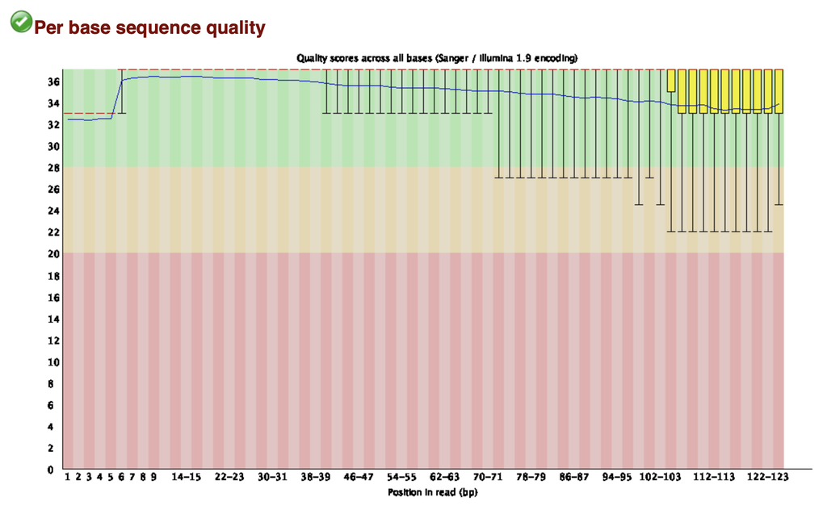

FastQC Per base sequence quality plot

The “Overrepresented sequences” table displays the sequences (at least 20 bp) that occur in more than 0.1% of the total number of sequences. This table aids in identifying contamination, such as vector or adapter sequences.

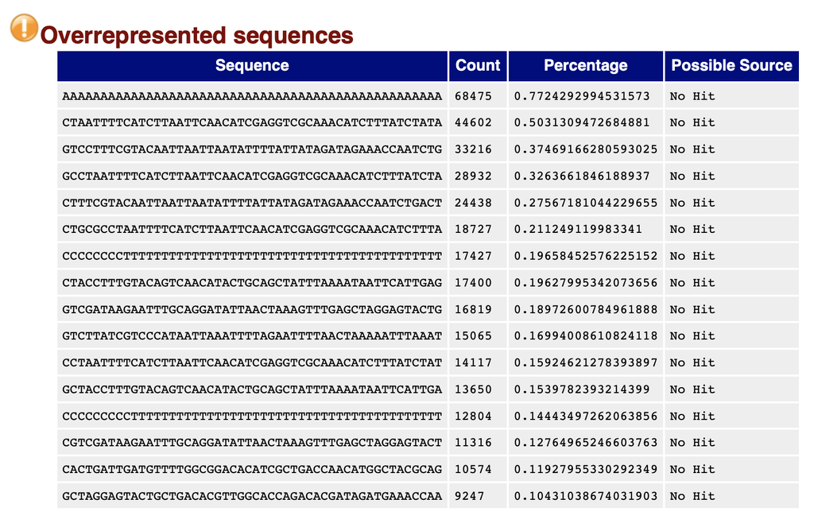

FastQC Overrepresented sequences plot

The top 2 overrepresented sequences for `SRR13397503_1_val_1.fq` reveal two common sources of contamination in RNA-seq libraries: 1) poly(A) (Sangiovanni et al., 2019), and 2) mitochondrial (Ilicic et al., 2016). Why suggest that the overrepresented sequence `CTAATTTTCATCTTAATTCAACATCGAGGTCGCAAACATCTTTATCTATA` indicates mitochondrial contamination? And what should we/can we do if we think our libraries have been contaminated in some way? (Think about this on your own and we will discuss in class!)

#### 4.5.3.1 Exersize: BLAST search of overrepresented sequences

It can be informative to BLAST search overrepresented sequences. Copy the sequence above, go to https://blast.ncbi.nlm.nih.gov/Blast.cgi?PAGE_TYPE=BlastSearch and run a search (either megablast or blastn is fine.)

### 4.5.4 Read pseudo-alignment (kallisto)

Assuming everything looks alright, the final step in the pipeline (before analysis of the resultant gene expression data) is to align our reads to a reference genome and then count the number of reads that aligned across gene transcript intervals.

Arguably, this is the step that requires the most intellectual input, in part due to there being different *methods* of read alignment (as well as many different tools one could use to implement a given method). What we will not do in this course is technically dissect each method or give an argument about whether one particular method is *better*; several reviews have been written about this subject (Crochet et al., 2020). That said, let’s at least talk about what the two main types of read alignment tools are - classic read alignment and pseudoalignment - and why we will use the latter in this workshop.

Contrary to normal read alignment, where we specify where the read aligns and how, i.e. how the nucleotides in the read match up with the nucleotides in the target sequence, a pseudoalignment of a read is simply a set of target sequences that the read is compatible with. A more precise definition and discussion can be found in [Lior Pachter’s blog post, “What is a read mapping”](https://liorpachter.wordpress.com/2015/11/01/what-is-a-read-mapping/).

The definition of pseudoalignment is crafted so that the output is a sufficient statistic for the basic RNA-Seq quantification model. As such, the focus is on sets of transcripts with counts rather than detailed alignments. While this makes pseudoalignments less intuitive than regular alignments, pseudoalignment tools - like **kallisto** - do impressively reduce the computational load, while remaining near-optimal in terms of alignment efficiency when compared to popular classical read alignment tools (Bray et al., 2016). Thus, it is the ideal method for at-home RNA-seq analysis!

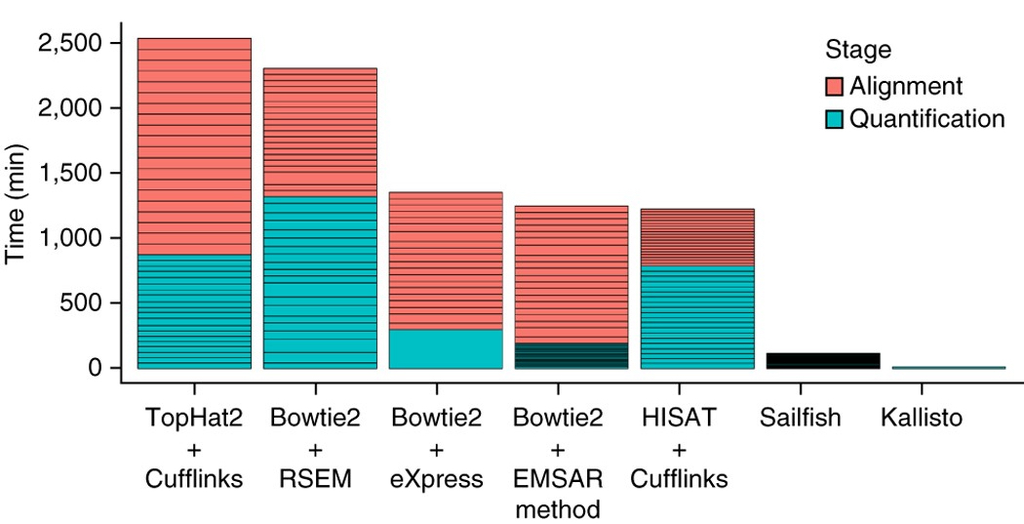

Total running time in minutes for processing 20 simulated data sets of 30 million paired-end reads.

#### 4.5.4.1 Making a kallisto reference transcriptome

In this workshop, we will use the popular pseudoalignment tool **kallisto** to generate counts of gene transcript abundances. In order to make the reference transcriptome for kallisto to find pseudoalignments on, we need the honey bee gene transcript sequences themselves. How do we get these? From the honey bee reference genome, of course!

**Step 1**: download a copy of the most recent honey bee reference genome (HAv3.1(Wallberg et al., 2019)) from NCBI in `.fasta` format. What is `.fasta` format? Think `.fastq`, minus all of the information that would only be relevant given the sequence in question has come from an NGS machine. [See a detailed description of the `.fasta` format here](https://zhanglab.ccmb.med.umich.edu/FASTA/).  
In your terminal:

```bash
GENOME_FILE=/volume/external/GCF_003254395.2_Amel_HAv3.1_genomic.fna.gz
wget -O ${GENOME_FILE} https://ftp.ncbi.nlm.nih.gov/genomes/all/GCF/003/254/395/GCF_003254395.2_Amel_HAv3.1/GCF_003254395.2_Amel_HAv3.1_genomic.fna.gz
```

If you unzip the file and open it in a text browser, you’ll see one `FASTA` entry for each of the honey bee chromosomes. How do we pull out *just* the gene transcript sequences? First, we’ll need a special type of data file called a **G**eneral **F**eature **F**ormat (**GFF**) file, which describes genes and other features of DNA, RNA and protein sequences. At the most basic level, its a file where each row corresponds to one genomic feature, detailing information about, most importantly: i) which chromosome it is on, ii) what kind of feature it is, and iii) its genomic interval, or *START* and *STOP* coordinates on the chromosome.

**Step 2**: download a copy of the HAv3.1 GFF file from NCBI.  
In your terminal:

```bash
GFF_FILE=/volume/external/GCF_003254395.2_Amel_HAv3.1_genomic.gff.gz
wget -O ${GFF_FILE} https://ftp.ncbi.nlm.nih.gov/genomes/all/GCF/003/254/395/GCF_003254395.2_Amel_HAv3.1/GCF_003254395.2_Amel_HAv3.1_genomic.gff.gz
```

Both files are compressed `.gz` archives, which we need to decompress.

**Step 3**: `gunzip` both files:

```bash
gunzip ${GENOME_FILE}
gunzip ${GFF_FILE}
```

Now, we will use a dependency of `bedtools`, which we installed earlier, to extract the gene transcript sequences from the `.fasta` reference genome file using the intervals specified in the `.gff` file.

**Step 4**: call `gffread` to extract the gene transcript sequences.  
In terminal:

```bash
GENOME_FILE=/volume/external/GCF_003254395.2_Amel_HAv3.1_genomic.fna
GFF_FILE=/volume/external/GCF_003254395.2_Amel_HAv3.1_genomic.gff
CDS_FILE=/volume/external/Amel_Hav3.1_transcripts.fasta

gffread ${GFF_FILE} -g ${GENOME_FILE} -w ${OUT_FILE} -F
```

**Step 5**: finally, call `kallisto index` to build the reference transcriptome alignment index using our `CDS_FILE`:

```bash
kallisto index --make-unique -i kallisto_Amel_HAv3.1 Amel_HAv3.1_transcripts.fasta
```

#### 4.5.4.2 Generate honey bee brain transcript abundances with kallisto

**Challenge!** (also, it’s just getting late and I’ve been working all day and will give a follow up tomorrow…)

See if you can follow the `kallisto count` documentation and generate the transcript abundances for our `SRR13397503` example sequencing reads. Best of luck, and kick ass!

## 4.6 Full tutorial

### 4.6.1 Retrieve data

In this tutorial, we will be working with a dataset synthesized from SRA Project [`SRP242105`](https://trace.ncbi.nlm.nih.gov/Traces/sra/?study=SRP242105) for BioProject [`PRJNA601517`](https://www.ncbi.nlm.nih.gov//bioproject/PRJNA601517), available here:

- [Synthetic SRP242105 for full tutorial](https://drive.google.com/file/d/1h9318eWOoCKgBX27g9pSARDUgWWF-XTs/view?usp=sharing)

Even though we will not be retrieving the data from SRA, we will use the accession list and metadata files. Go to the [`SRP242105` run selector](https://trace.ncbi.nlm.nih.gov/Traces/study/?acc=SRP242105&o=acc_s%3Aa) and download the `Metadata` and `Accession List` files, and place them in the `/volume/external` sub-directory of our R Project directory. The file will be titled `SRR_Acc_List.txt.csv`. We can feed this directly into a bash array. In terminal:

```bash
cd #your cloned repository directory
SRA_LIST=()
while IFS= read -r line; do
  SRA_LIST+=("$line")
done < volume/external/SRR_Acc_List.txt.csv
```

Everything from this point on to the last step is the same as the short tutorial. If you were retrieving the raw data from SRA, you would run a loop, calling `prefetch` and `fasterq-dump` on the ’i’th index of `SRA_LIST`. In terminal:

```bash
EXT_DIR="${DIR}/volume/external"
echo "/repository/user/main/public/root = \"$EXT_DIR\"" > $HOME/.ncbi/user-settings.mkfg

for i in "${SRA_LIST[@]}"; do
  prefetch ${i}
  fasterq-dump -O ${EXT_DIR} ${i}
done
```

### 4.6.2 Trim adapters

Here is where you’ll actually start for the tutorial. First, gunzip the synthetic dataset contained in the `raw.tar.gz` archive into the `/volume/raw` sub-directory. In terminal:

```bash
cd ${EXT_DIR}
gunzip raw.tar.gz /volume/raw
```

Next, trim adapters from the reads:

```bash
cd #path/to/your/directory/volume/raw
FILE_LIST=*.gz
OUT_DIR="/path/to/your/directory/volume/interim"
trim_galore --fastqc -j 4 --paired ${FILE_LIST[*]} -o ${OUT_DIR}
```

### 4.6.3 Pseudo-alignment

We have to do something a little tricky here since we’re working with paired-end files, and need to call `kallisto quant` on each pair. Thankfully, directories are sorted by name, so each paired-end `.fastq` file should be listed next to each other. But, we need a way to tell bash to work with only that pair, and no other files, for each iteration of a loop. In this case, we declare a `COUNTER` variable set to 0, and tell bash to run a loop `while` `COUNTER` is less than the length of `FILE_LIST`. However, during each iteration, we want to increase `COUNTER` by 2, so that we start with mate 1 of the next set of paired-end files at the start of the loop. Thus, we tell `kallisto quant` to quantify transcript abundances on the ‘`COUNTER`’th index of `FILE_LIST` as well as the’`COUNTER2`’th index of `FILE_LIST` (which we declare within the loop as `COUNTER`+1, i.e., mate 2 of the set of paired-end files.)

```bash
FILE_LIST=(*.gz)
len=${#FILE_LIST[@]}
COUNTER=0
OUT_DIR="/Volumes/Sean/RNAseqWorkshop/data/res"
while [  $COUNTER -lt ${len} ]; do
  declare -i COUNTER2=${COUNTER}+1
  OUT_FILES=${OUT_DIR}/${FILE_LIST[${COUNTER}]%%_*}
  kallisto quant -i /Volumes/Sean/RNAseqWorkshop/index/kallisto_Amel_HAv3.1 -o ${OUT_FILES} -t 2 ${FILE_LIST[${COUNTER}]} ${FILE_LIST[${COUNTER2}]}
  let COUNTER=COUNTER+2
done
```

### 4.6.4 Generate count matrix (tximport)

Finally, we can convert the `abundance.tsv` files output by `kallisto quant` (into separate directories of `/output`) into a single count matrix.

Create a new R project within the `/RNAseq-to-DEGs` directory.

Install the following packages in R:

```r
if (!requireNamespace("BiocManager", quietly = TRUE))
    install.packages("BiocManager")

BiocManager::install("Biostrings")
BiocManager::install("tximport")

library(Biostrings)
library(tximport)
```

```r
# Create a data.frame containing the transcript names
headers <- data.frame(name.full=names(readDNAStringSet(filepath = 'volume/external/Amel_HAv3.1_transcripts.fasta', format="fasta")))
# ---------- #

# Buckle up: things get a little complex here. This next section is a script which takes the "headers" data.frame above and creates a new data.frame "tx2gene" with four columns containing the transcript ID minus its categorical classifier ('rna-'), its corresponding gene ID, the "gbkey" value from column 3 of the gff, and the transcript ID.
# NOTE: this only needs to be completed once. You can begin with the tx2gene.csv file.

## Create some empty lists
headers.rna <- list()
headers.gene <- list()
headers.type <- list()
## For each row (i) in "headers", run this loop
for(i in 1:length(headers[[1]])){
  # Get the value in column 1 row i
  x = headers[[1]][i]
  # Split this string by " "
  xx = unlist(strsplit(x," "))
  # Get element containing "rna-"
  xxx1 = grep("rna-", xx,value=T)
  # If column 1 row i does not contain "rna-", set to "NA-NA"
  if(isEmpty(xxx1)){xxx1 = "NA-NA"}
  # Split this string by "-", keeping only the characters after "-"
  xxxx1 = substring(xxx1, regexpr("-", xxx1) + 1, nchar(xxx1))
  # Add this value to a list
  headers.rna[i] <- xxxx1

  # Get the element containing "GeneID"
  xxx2 = grep("GeneID", xx,value=T)[1]
  # If column 1 row i does not contain "GeneID", set to "NA-NA". Or else,
  if(isEmpty(xxx2)){xxx2 = "NA-NA"}else{
    # Split this string by ","
    xxxx2 = unlist(strsplit(xxx2,","))
    # Get the element containing "GeneID"
    xxxxx2 = grep("GeneID", xxxx2, value=T)
    # If column 1 row i does not contain "GeneID", set to "NA-NA"
    if(isEmpty(xxxxx2)){xxxxx2 = "NA:NA"}
    # Split this string by ":", keeping only the characters after ":"
    xxxxxx2 = sapply(strsplit(xxxxx2,":"), "[", 2)
    # Add this value to a list
    headers.gene[i] <- xxxxxx2}

  # Get the element containing "gbkey"
  xxx3 = grep("gbkey", xx,value=T)[1]
  # If column 1 row i does not contain "gbkey", set to "NA-NA"
  if(isEmpty(xxx3)){xxx3 = "NA=NA"}
  # Split this string by "=", keeping only the characters after "="
  xxxx3 = sapply(strsplit(xxx3,"="), "[", 2)
  # Add this value to a list
  headers.type[i] <- xxxx3
}

# Create a data.frame with three columns filled with the values from our lists above
tx2gene <- data.frame(tx_id_ref=unlist(headers.rna),
                      gene_id=unlist(headers.gene),
                      type=unlist(headers.type))
# Add a fourth column by splitting column 1 by "-" and keeping only the characters after "-"
tx2gene$tx_id <- paste("rna",tx2gene$tx_id_ref,sep="-")
# Save this to a csv
write.csv(tx2gene,"volume/external/tx2gene.csv",row.names=F)
# Delete temp values
rm(headers.gene,headers.rna,headers.type,i,x,xx,
   xx1,xx2,xx3,xxxx1,xxx1,xxx2,xxx3,
   xxxx2,xxxx3,xxxxx2,xxxxxx2)
# ---------- #

# NOTE: START HERE IF YOU'VE ALREADY MADE tx2gene.csv!!!
# Go through each sub-directory in `output` and add the file path to the "abundance.tsv" within them to a list
tx2gene <- read.csv("volume/external/tx2gene.csv")
tx2gene$gene_id <- as.character(tx2gene$gene_id)
dirs.kallisto <- list.dirs("output", recursive=FALSE)
files.list <- list()
for (i in 1:length(dirs.kallisto)){
  FILEi <- paste(unlist(dirs.kallisto[i]),"abundance.tsv",sep="/")
  files.list[[i]] <- FILEi
  rm(FILEi)
}
# Keep only rows of tx2gene that do not correspond to gene intervals
tx2gene_txi <- tx2gene[-grep("Gene",tx2gene$type),c("tx_id","gene_id")]
tx2gene_txi <- tx2gene_txi[complete.cases(tx2gene_txi), ]
# Delete temp values
rm(i)
# ---------- #

# Generate the counts matrix by tximport method
txi <- tximport(unlist(files.list), type = "kallisto",
                tx2gene = tx2gene_txi,
                geneIdCol="gene_id",
                txIdCol="tx_id")
datExpr <- as.data.frame(txi[["counts"]])

# Get the accession number from each file path in files.list and set datExpr column names
names.datExpr <- list()
for(i in 1:length(unlist(files.list))){
  names.datExpr[i] <- sapply(strsplit(unlist(files.list)[i],"/"), "[", 2)
}
rm(i)
names(datExpr) <- names.datExpr
datExpr <- as.matrix(datExpr)
# Delete any rows named "NA"
datExpr <- datExpr[!dimnames(datExpr)[1]%in%c("NA"),]

# Save the counts matrix to counts.csv
write.csv(datExpr,"output/counts.csv")

# Delete temp values
rm(x,names.datExpr,headers,file.list,files.list,sra.list,
   tx2gene,tx2gene_txi,txi,dirs.kallisto)
```

If everything goes smoothly, you should have created a `counts.csv` file that looks like this (displaying the first 5 samples):

Table 1: head of counts.csv

|  | SRR10901285 | SRR10901286 | SRR10901287 | SRR10901288 | SRR10901289 |
| --- | --- | --- | --- | --- | --- |
| 100037419 | 3365.00000 | 3354.00000 | 1 | 1 | 2.00000 |
| 100049551 | 6.00000 | 5.00000 | 0 | 2 | 2.80384 |
| 100049563 | 4.54356 | 5.60704 | 0 | 0 | 0.00000 |
| 100049571 | 3352.00000 | 3317.00000 | 362 | 358 | 331.00000 |
| 100049572 | 1.02555 | 2.01582 | 0 | 1 | 1.00000 |
| 100126690 | 36.00000 | 34.00000 | 0 | 0 | 0.00000 |

# 5 Session 3: DEG analysis, from count matrices to DEGs (and what they’re good for)

[Under development…]

# 6 Preparing markdown and $L^{A}T_{E}X$ documents for scientific communication

[Under development…]

# 8 References

- [Happy Git and GitHub for the useR by Jennifer Bryan](https://happygitwithr.com)
- [Cookiecutter Data Science](https://drivendata.github.io/cookiecutter-data-science/#cookiecutter-data-science)
- [R Best Practices by Krista L. DeStasio](https://kdestasio.github.io/post/r_best_practices/)
- [project_template GitHub repository - Drew Wham](https://github.com/DrewWham/project_template)
- [Project-oriented workflow by Jenny Bryan](https://www.tidyverse.org/blog/2017/12/workflow-vs-script/)
- [R for Data Science by Wickham & Grolemund](https://r4ds.had.co.nz/workflow-projects.html)
- [Why I want to write nice R code by Daniel Falster](https://nicercode.github.io/blog/2013-04-05-why-nice-code/)

Bray, N. L., Pimentel, H., Melsted, P., & Pachter, L. (2016). Near-optimal probabilistic RNA-seq quantification. *Nat Biotechnol*, *34*(5), 525–527. https://doi.org/10.1038/nbt.3519

Crochet, L., Rojas, E., Alonso-Lopez, D., Rivas, J., Gutierrez, N., & Burguillo, F. (2020). Systematic comparison and assessment of RNA-seq procedures for gene expression quantitative analysis. *Scientific Reports*, *10*.

Denlinger, D. L., & Armbruster, P. A. (2013). Mosquito Diapause. *Ann Rev Entomol*, 24.

Doke, M., McGrady, C., Otieno, M., Grozinger, C., & Frazier, M. (2019). Colony size, rather than geographic origin of stocks, predicts overwintering success in honey bees, hymenoptera apidae, in the northeastern united states. *Journal of Economic Entomology*, *112*(2), 525–533.

Ilicic, T., Kim, J., & Kolodziejczyk, A. (2016). Classification of low quality cells from single-cell RNA-seq data. *Genome Biology*, *17*(29).

Sangiovanni, M., Granata, I., Thind, A., & Guarracino, M. (2019). From trash to treasure: Detecting unexpected contamination in unmapped NGS data. *BMC Bioinformatics*, *20*(4).

Saulich, A., & Musolin, D. (2017). Summer Diapause as a Special Seasonal Adaptation in Insects: Diversity of Forms, Control Mechanisms, and Ecological Importance. *Entomological Review*, *97*(9), 1183–1212.

Sim, C., & Denlinger, D. L. (2013). Insulin signaling and the regulation of insect diapause. *Frontiers in Physiology*, 10.

Wallberg, A., Bunikis, I., Pettersson, O. V., Mosbech, M.-B., Childers, A. K., Evans, J. D., Mikheyev, A. S., Robertson, H. M., Robinson, G. E., & Webster, M. T. (2019). A hybrid de novo genome assembly of the honeybee, Apis mellifera, with chromosome-length scaffolds. *BMC Genomics*, *20*(1), 275. https://doi.org/10.1186/s12864-019-5642-0